# Code - From little things, big things grow: using applied nucleation to restore marine forests

### **2h)** Gforce

1. Check data structure

```r
str(Gforce)
```

```
## spc_tbl_ [248,038 × 10] (S3: spec_tbl_df/tbl_df/tbl/data.frame)
##  $ Site_Code           : chr [1:248038] "BB" "BB" "BB" "BB" ...
##  $ #                   : num [1:248038] 1 2 3 4 5 6 7 8 9 10 ...
##  $ Date Time, GMT+11:00: chr [1:248038] "12/13/17 06:00:00 am" "12/13/17 06:05:00 am" "12/13/17 06:10:00 am" "12/13/17 06:15:00 am" ...
##  $ X                   : num [1:248038] 0.025 0.125 0.025 -0.1 0.025 0.075 -0.125 -0.25 0.025 -0.125 ...
##  $ Y                   : num [1:248038] -0.375 -0.475 -0.375 -0.375 -0.425 -0.4 -0.125 -0.225 -0.375 -0.25 ...
##  $ Z                   : num [1:248038] 0.925 0.85 0.95 0.925 0.9 0.925 1 0.875 0.925 1.05 ...
##  $ Date                : Date[1:248038], format: "2017-12-13" "2017-12-13" ...
##  $ Time                : 'hms' num [1:248038] 06:00:00 06:05:00 06:10:00 06:15:00 ...
##   ..- attr(*, "units")= chr "secs"
##  $ GMT+11:00           : chr [1:248038] "am" "am" "am" "am" ...
##  $ SD_acceleration     : num [1:248038] 0.998 0.982 1.022 1.003 0.996 ...
##  - attr(*, "spec")=
##   .. cols(
##   ..   Site_Code = col_character(),
##   ..   `#` = col_double(),
##   ..   `Date Time, GMT+11:00` = col_character(),
##   ..   X = col_double(),
##   ..   Y = col_double(),
##   ..   Z = col_double(),
##   ..   Date = col_date(format = "%d/%m/%Y"),
##   ..   Time = col_time(format = ""),
##   ..   `GMT+11:00` = col_character(),
##   ..   SD_acceleration = col_double()
##   .. )
##  - attr(*, "problems")=<externalptr>
```

2. Filter data - select only restored sites

```r
Gforce <- Gforce %>%
filter(Site_Code == "SO"| Site_Code == "MA"|Site_Code == "CO"|Site_Code == "FW"| Site_Code == "WB")
```

3. Calculate daily SD

```r
Gforce_DailySD1 <- Gforce %>%
  group_by(Site_Code, Date)%>%
  summarise(DailySD = sd(SD_acceleration))
```

4. Visualise G force data variation

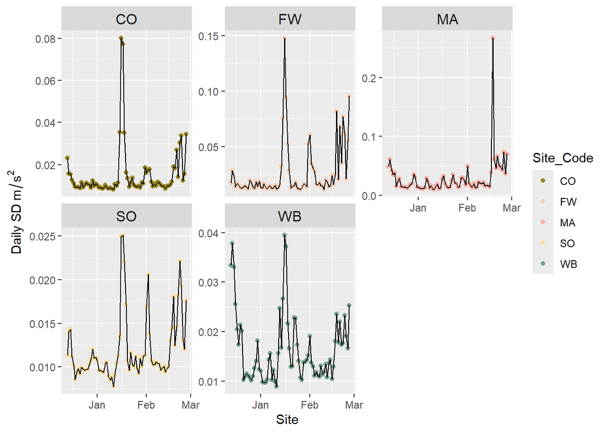

```r
Gforce_DailySD1 %>%
 ggplot(aes(x= Date, y= DailySD)) +
geom_point(aes(color = Site_Code)) +
geom_line()+
labs(y = expression ("Daily SD"~m/s^2), x = "Site") +
facet_wrap(~ Site_Code, scales = "free_y") +
theme(strip.text.x = element_text(size = 12)) +
scale_color_manual(values=wes_palette(n=5, name="Royal2"))
```

5. Calculate mean per site

```r
Gforce_mean <- Gforce %>%
  group_by(Site_Code)%>%
  summarise(Mean_SD = sd(SD_acceleration))
```

### **2i)** UVC_Cryptic

1. Check data structure

```r
str(Cryptic_V1)
```

```
## 'data.frame':    177 obs. of  133 variables:
##  $ Survey_Period                                            : int  1 1 1 1 1 1 1 1 1 1 ...
##  $ Time                                                     : chr  "BEFORE" "BEFORE" "BEFORE" "BEFORE" ...
##  $ Date                                                     : chr  "16/07/2017" "16/07/2017" "16/07/2017" "16/07/2017" ...
##  $ Cryptic_Diver                                            : chr  "George" "George" "George" "George" ...
##  $ Inverts_Diver                                            : chr  "Damon Bolton" "Damon Bolton" "Damon Bolton" "Damon Bolton" ...
##  $ Site_Code                                                : chr  "CO" "CO" "CO" "CO" ...
##  $ Status                                                   : chr  "TRANSPLANT" "TRANSPLANT" "TRANSPLANT" "TRANSPLANT" ...
##  $ Transect_number                                          : int  1 2 3 4 1 2 3 4 1 2 ...
##  $ Temperature_water                                        : int  18 18 18 18 19 19 19 19 18 18 ...
##  $ Abalone                                                  : int  0 0 0 0 0 0 0 NA 0 0 ...
##  $ Crayfish                                                 : int  0 0 0 0 0 0 0 NA 0 0 ...
##  $ Dicathais_orbita                                         : int  NA NA NA NA NA NA NA NA NA NA ...
##  $ Ranella_australasia                                      : int  NA NA NA NA NA NA NA NA NA NA ...
##  $ Australium_tentorififormis                               : int  NA NA NA NA NA NA NA NA NA NA ...
```

[output cut: 86 more lines]

2. Change to long format

```r
Cryptic_long <- Cryptic_V1  %>%
  mutate(across(everything(), ~ifelse(.=="", NA, as.character(.))))  %>%
  gather(Species, Abundance, Abalone:white_nudibranch_black_edges)
```

3. Filter data - Remove all rows that are not numbers including n/a, join with species list and filter only restored sites

```r
Cryptic_long$Survey_Period <- as.factor(Cryptic_long$Survey_Period)
Cryptic_long$Abundance <- as.numeric(Cryptic_long$Abundance)
Cryptic_long <- Cryptic_long %>%
filter(!is.na(Abundance)) %>%
left_join(Species, by = c("Species")) %>%
filter(Site_Code == "SO"| Site_Code == "MA"|Site_Code == "CO"|Site_Code == "FW"| Site_Code == "WB")
```

4. Calculate mean abundance and return to wide format

```r
Cryptic_sum <- Cryptic_long %>%
  group_by(Site_Code, Species) %>%
  summarise(Total_abundance = mean(Abundance))
Cryptic_wide <- Cryptic_sum %>%
ungroup() %>%
pivot_wider(names_from = Species, values_from = Total_abundance, values_fill = 0)
```

5. Calculate total abundance by functional group + mean transects

```r
Cryptic_group <- Cryptic_long %>%
  group_by(Survey_Period, Site_Code, Transect_number, Functional_group)%>%
  summarise(Sum_Abundance = sum(Abundance))

Group_wide <- Cryptic_group %>%
ungroup() %>%
pivot_wider(names_from = Functional_group, values_from = Sum_Abundance, values_fill = 0)

Group_long <- Group_wide %>%
  gather(Functional_group, Sum_Abundance, Fish_predator:Shrimp)

Cryptic_group_mean <- Group_long %>%
  group_by(Survey_Period, Site_Code, Functional_group)%>%
  summarise(Mean_Abundance = mean(Sum_Abundance), n = n(), coef_Sum_Abundance = (sd(Sum_Abundance)/ mean(Sum_Abundance)) * 100)


Group_mean_merged <- Group_long %>%
  group_by(Site_Code, Functional_group)%>%
  summarise(Mean_Abundance = mean(Sum_Abundance), n = n(), coef_Sum_Abundance = (sd(Sum_Abundance)/ mean(Sum_Abundance)) * 100)
```

6. Calculate total abundance by taxa + mean transects

```r
Cryptic_taxa <- Cryptic_long %>%
  group_by(Survey_Period, Site_Code, Time, Status, Transect_number, Taxa)%>%
  summarise(Sum_Abundance = sum(Abundance))

Cryptic_taxa_mean <- Cryptic_taxa %>%
  group_by(Survey_Period, Time, Site_Code, Status, Taxa)%>%
  summarise(Mean_Abundance = mean(Sum_Abundance),n = n(), sd = sd(Sum_Abundance), se = sd/sqrt(n), coef_Sum_Abundance = (sd(Sum_Abundance)/ mean(Sum_Abundance)) * 100)

Taxa_mean_merged <- Cryptic_taxa %>%
  group_by(Site_Code, Taxa)%>%
  summarise(Mean_Abundance = mean(Sum_Abundance),n = n(), sd = sd(Sum_Abundance), se = sd/sqrt(n), coef_Sum_Abundance = (sd(Sum_Abundance)/ mean(Sum_Abundance)) * 100)
```

### **2j)** Mobile fish

1. Check data structure

```r
str(Mobile_fish)
```

```
## 'data.frame':    870 obs. of  13 variables:
##  $ Site_Code    : chr  "FW" "FW" "FW" "FW" ...
##  $ Month        : chr  "October" "October" "October" "October" ...
##  $ Year         : int  2017 2017 2017 2017 2017 2017 2017 2017 2017 2017 ...
##  $ Survey_Period: int  2 2 2 2 2 2 2 2 2 2 ...
##  $ TapeReader   : chr  "Anthony" "Anthony" "Anthony" "Anthony" ...
##  $ Transect     : int  1 1 1 1 1 1 1 1 1 1 ...
##  $ Time..mins.  : num  6.94 7.08 7.52 7.53 7.58 ...
##  $ Family       : chr  "" "" "Pomacentridae" "Pomacentridae" ...
##  $ Genus        : chr  "Atypichthys" "Atypichthys" "Parma" "Parma" ...
##  $ Species      : chr  "strigatus" "strigatus" "microlepis" "spp" ...
##  $ Species_name : chr  "Atypichthys_strigatus" "Atypichthys_strigatus" "Parma_microlepis" "Parma_spp." ...
##  $ Number       : int  1 1 1 1 1 1 1 1 1 1 ...
##  $ Activity     : chr  "Passing" "Passing" "Passing" "Passing" ...
```

2. Calculate total abundance per transect

```r
Fish_per_video <- Mobile_fish %>%
  group_by(Site_Code, Species_name,Transect) %>%
  summarise(Abundance = sum(Number))
```

3. Convert to the wide format and add zero for species not present

```r
Fish_wide <- Fish_per_video %>%
  spread(Species_name, Abundance,fill = 0)
```

4. Convert back to long format

```r
Fish_long <- Fish_wide %>%
 pivot_longer(cols = `Achroerodus_viridis`:`Unidentified`,
    names_to = "Species_name",
    values_to = "Abundance",
    values_transform = ~ as.numeric(gsub(",", "", .x)))
```

5. Join with species groups

```r
Mobile_fish_all <- Fish_long  %>%
left_join(Species_mobile, by = c("Species_name"))
```

6. Sum of Aundance per video per functional group

```r
Funct_fish <- Mobile_fish_all %>%
  group_by(Site_Code, Transect, Functional_group) %>%
  summarise(Sum_Abundance = sum(Abundance))
Herbs <-  Funct_fish %>%
  filter (Functional_group == "Herbivore"| Functional_group == "Omnivore")%>%
  group_by(Site_Code, Transect) %>%
  summarise(Sum_Abundance = sum(Sum_Abundance))
```

7. Calculate mean abundance per site

```r
Funct_fish_herb <- Herbs %>%
  group_by(Site_Code) %>%
  summarise(Mean_Abundance = mean(Sum_Abundance), sd = sd(Sum_Abundance))
```

### **2k)** Species Richness

1. Calculate sum of all species in the same site and census (including transects and DOV).

```r
Mobile_fish_all1 <- rename(Mobile_fish_all,"Species" = "Species_name")
Cryptic_long1 <- Cryptic_long %>%
  dplyr::select(Site_Code, Survey_Period, Species, Abundance, Functional_group)

All_methods <- rbind(Mobile_fish_all1, Cryptic_long1)
```

2. Calculate herbivore species richness

```r
MobileSUM <- All_methods %>%
  group_by(Site_Code, Species, Functional_group) %>%
  summarise(Abundance = sum(Abundance)) %>%
  mutate(Presence = if_else(Abundance > 0,1,0))
AbundancesHerb <- MobileSUM %>%
  filter(Functional_group == "Omnivorous_fish" | Functional_group == "Herbivore"| Functional_group == "Herbivorous_invert"| Functional_group == "Urchin"| Functional_group == "Omnivore")

RichnessHerb <- AbundancesHerb %>%
  group_by(Site_Code)%>%
  summarise(Richness = sum(Presence))
```

### **2l)** Community composition

1. Clean and standardise stand dataset

```r
which(colSums(Cryptic_wide!= 0) == 0)
```

```
## jumpy_brown
##          30
```

```r
Cryptic_wide1 <- Cryptic_wide[ -c(30)]
which(rowSums(Cryptic_wide1[,5:50] != 0) == 0) # Remove columns and rows with only 0 occurrences
```

```
## integer(0)
```

```r
Cryptic_val <- Cryptic_wide1 %>%
  dplyr::select(- Site_Code)

Cryptic_stand <- decostand(Cryptic_val, method = "total") #standardise by total
```

2. Run PCoA

```r
Cryptic_comp <- vegdist(Cryptic_stand, "bray")
pcoa <- cmdscale(Cryptic_comp, eig = TRUE, add = TRUE)
pcoa$eig
```

```
## [1]  1.896204e-01  8.464614e-02  4.655751e-02  1.906806e-02 -1.838868e-18
```

```r
#convert pcoa results into data frame that can be plotted
pcoa_df <- data.frame(pcoa$points)
colnames(pcoa_df) <- c("PCo1", "PCo2")

pcoa_df$Site_Code <- factor(Cryptic_wide$Site_Code)
```

## **Part 3:** Recruitment patterns by site

*Set general theme for plots*

```r
Theme1 <- theme_bw() +
    theme(panel.grid.major = element_line(colour = "white"),
          panel.grid.minor = element_line(colour = "white"), axis.text.y = element_text(size = 12), axis.title.y = element_text(size = 12), axis.text.x = element_text(size = 12), axis.title.x =     element_text(size = 12), plot.title=element_text(hjust=0.95, vjust=-8, size=12), axis.ticks = element_blank())
```

#### **3a)** Visualise patterns

*2.* Density post-transplantation

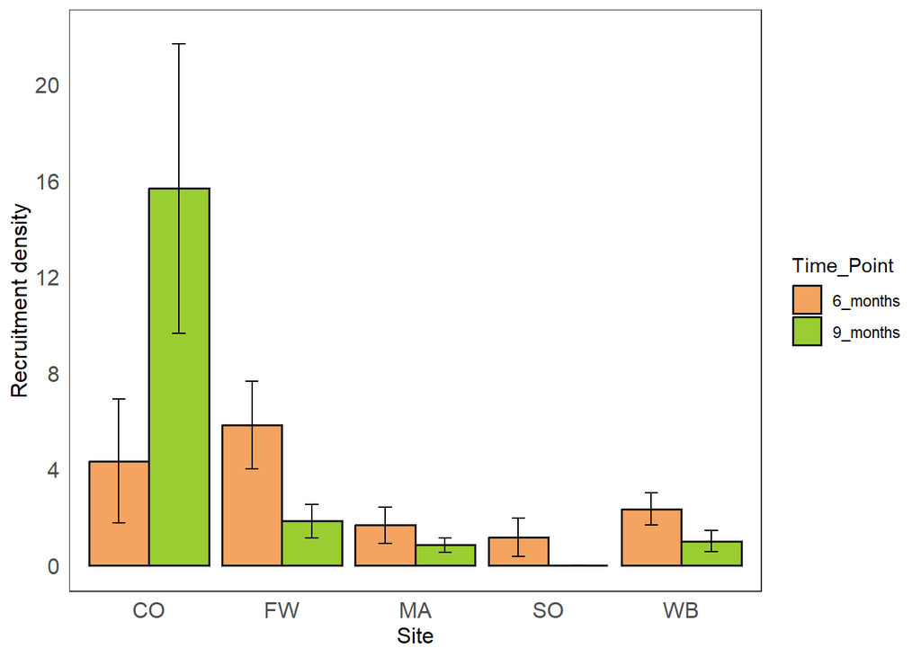

```r
Recruitment_mean %>%
ggplot(aes(x= Site_Code, y=Recruitment_mean, fill = Time_Point)) +
geom_bar(stat="identity", color="grey10", size=0.65, position=position_dodge()) +
 geom_errorbar(aes(ymin=Recruitment_mean-se, ymax=Recruitment_mean+se), width=.2, position=position_dodge(0.9)) +
  Theme1 +
labs( y="Recruitment density", x="Site") +
theme(axis.title.x=element_text(size = 12),
        axis.text.x=element_text(size =12), axis.text.y = element_text(size = 12), axis.title.y = element_text(size = 12)) +
scale_fill_manual(values=wes_palette(n=5, name="Royal2")) +
  scale_y_continuous(limits = c(0, 22), breaks = seq(0,20, by = 4)) +
  scale_fill_manual(values = c("sandybrown", "olivedrab3"))
```

```r
ggsave("Recruitscount.jpeg", width = 12, height = 7.5, units = "cm")
```

*3.* Length post-transplantation

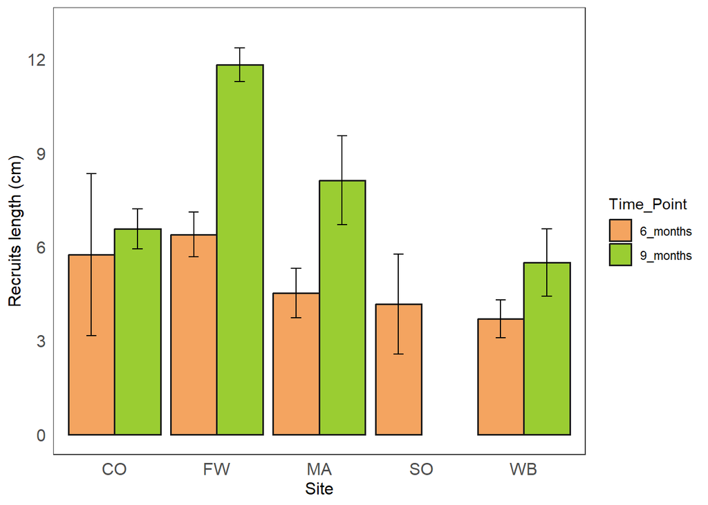

```r
Recruits_size_mean %>%
ggplot(aes(x= Site_Code, y=Recruit_size_mean, fill = Time_Point)) +
geom_bar(stat="identity", color="grey10", size=0.7, position=position_dodge()) +
 geom_errorbar(aes(ymin=Recruit_size_mean-se, ymax=Recruit_size_mean+se), width=.2, position=position_dodge(0.9)) +
  Theme1 +
labs( y="Recruits length (cm)", x="Site") +
theme(axis.title.x=element_text(size = 12),
        axis.text.x=element_text(size =12), axis.text.y = element_text(size = 12), axis.title.y = element_text(size = 12)) +
  scale_y_continuous(limits = c(0, 13), breaks = seq(0, 12, by = 3)) +
  scale_fill_manual(values = c("sandybrown", "olivedrab3"))
```

```r
ggsave("RecruitsSize.jpeg", width = 12, height = 7.5, units = "cm")
```

#### **3b)** Analyse patterns

Differences in recruitment density and length were evaluated over time, also exploring the effect of site as a random factor.

*1* Recruitment density 6 and 9 months post-transplantation

```r
Recruitment_density$Time_Point <- as.factor(Recruitment_density$Time_Point)
model4 <- lmer(sqrt(Total_recruitment) ~ Time_Point + (1 + Time_Point|Site_Code), data=Recruitment_density)
model5 <- lmer(sqrt(Total_recruitment) ~ Time_Point + (1|Site_Code), data=Recruitment_density) #modified for a non-balanced dataset
summary(model4)
```

```
## Linear mixed model fit by REML. t-tests use Satterthwaite's method [
## lmerModLmerTest]
## Formula: sqrt(Total_recruitment) ~ Time_Point + (1 + Time_Point | Site_Code)
##    Data: Recruitment_density
##
## REML criterion at convergence: 183.5
##
## Scaled residuals:
##     Min      1Q  Median      3Q     Max
## -1.9165 -0.7464 -0.0442  0.5637  3.1425
##
## Random effects:
##  Groups    Name               Variance Std.Dev. Corr
##  Site_Code (Intercept)        0.2055   0.4533
##            Time_Point9_months 1.1409   1.0681   0.38
##  Residual                     1.0030   1.0015
## Number of obs: 60, groups:  Site_Code, 5
##
## Fixed effects:
##                    Estimate Std. Error      df t value Pr(>|t|)
## (Intercept)          1.4054     0.2730  4.0001   5.148  0.00675 **
## Time_Point9_months  -0.1876     0.5432  4.0001  -0.345  0.74724
## ---
## Signif. codes:  0 '***' 0.001 '**' 0.01 '*' 0.05 '.' 0.1 ' ' 1
##
## Correlation of Fixed Effects:
##             (Intr)
## Tm_Pnt9_mnt 0.023
```

```r
anova(model4, model5)
```

```
## refitting model(s) with ML (instead of REML)
```

```
## Data: Recruitment_density
## Models:
## model5: sqrt(Total_recruitment) ~ Time_Point + (1 | Site_Code)
## model4: sqrt(Total_recruitment) ~ Time_Point + (1 + Time_Point | Site_Code)
##        npar    AIC    BIC  logLik deviance  Chisq Df Pr(>Chisq)
## model5    4 199.75 208.12 -95.873   191.75
## model4    6 195.11 207.68 -91.557   183.11 8.6326  2    0.01335 *
## ---
## Signif. codes:  0 '***' 0.001 '**' 0.01 '*' 0.05 '.' 0.1 ' ' 1
```

```r
rand(model4)
```

```
## ANOVA-like table for random-effects: Single term deletions
##
## Model:
## sqrt(Total_recruitment) ~ Time_Point + (1 + Time_Point | Site_Code)
##                                            npar  logLik    AIC    LRT Df
## <none>                                        6 -91.744 195.49
## Time_Point in (1 + Time_Point | Site_Code)    4 -96.281 200.56 9.0745  2
##                                            Pr(>Chisq)
## <none>
## Time_Point in (1 + Time_Point | Site_Code)     0.0107 *
## ---
## Signif. codes:  0 '***' 0.001 '**' 0.01 '*' 0.05 '.' 0.1 ' ' 1
```

Check assumptions

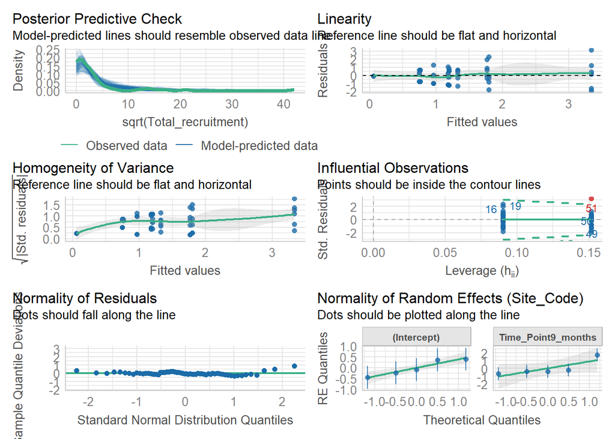

```r
check_model(model4)
```

*2* Recruitment length 6 and 9 months post-transplantation

```r
Recruits_length$Time_Point <- as.factor(Recruits_length$Time_Point)
model4 <- lmer(sqrt(Recruit_size_inside_mat) ~ Time_Point + (1 + Time_Point|Site_Code), data=Recruits_length)
```

```
## boundary (singular) fit: see help('isSingular')
```

```r
model5 <- lmer(sqrt(Recruit_size_inside_mat) ~ Time_Point + (1|Site_Code), data=Recruits_length)#modified for a non-balanced dataset
summary(model4)
```

```
## Linear mixed model fit by REML. t-tests use Satterthwaite's method [
## lmerModLmerTest]
## Formula: sqrt(Recruit_size_inside_mat) ~ Time_Point + (1 + Time_Point |
##     Site_Code)
##    Data: Recruits_length
##
## REML criterion at convergence: 60.7
##
## Scaled residuals:
##     Min      1Q  Median      3Q     Max
## -1.7901 -0.6261 -0.1192  0.6397  3.2605
##
## Random effects:
##  Groups    Name               Variance Std.Dev. Corr
##  Site_Code (Intercept)        0.04168  0.2042
##            Time_Point9_months 0.04989  0.2234   1.00
##  Residual                     0.23174  0.4814
## Number of obs: 38, groups:  Site_Code, 5
##
## Fixed effects:
##                    Estimate Std. Error     df t value Pr(>|t|)
## (Intercept)          2.1565     0.1399 6.0100  15.417 4.64e-06 ***
## Time_Point9_months   0.5843     0.1985 5.6962   2.943   0.0275 *
## ---
## Signif. codes:  0 '***' 0.001 '**' 0.01 '*' 0.05 '.' 0.1 ' ' 1
##
## Correlation of Fixed Effects:
##             (Intr)
## Tm_Pnt9_mnt -0.048
## optimizer (nloptwrap) convergence code: 0 (OK)
## boundary (singular) fit: see help('isSingular')
```

```r
anova(model4, model5)
```

```
## refitting model(s) with ML (instead of REML)
```

```
## Data: Recruits_length
## Models:
## model5: sqrt(Recruit_size_inside_mat) ~ Time_Point + (1 | Site_Code)
## model4: sqrt(Recruit_size_inside_mat) ~ Time_Point + (1 + Time_Point | Site_Code)
##        npar    AIC    BIC  logLik deviance  Chisq Df Pr(>Chisq)
## model5    4 66.484 73.034 -29.242   58.484
## model4    6 69.092 78.918 -28.546   57.092 1.3914  2     0.4987
```

```r
anova(model4)
```

```
## Type III Analysis of Variance Table with Satterthwaite's method
##            Sum Sq Mean Sq NumDF  DenDF F value  Pr(>F)
## Time_Point  2.007   2.007     1 5.6962  8.6604 0.02749 *
## ---
## Signif. codes:  0 '***' 0.001 '**' 0.01 '*' 0.05 '.' 0.1 ' ' 1
```

```r
rand(model4)
```

```
## ANOVA-like table for random-effects: Single term deletions
##
## Model:
## sqrt(Recruit_size_inside_mat) ~ Time_Point + (1 + Time_Point | Site_Code)
##                                            npar  logLik    AIC    LRT Df
## <none>                                        6 -30.365 72.730
## Time_Point in (1 + Time_Point | Site_Code)    4 -31.134 70.268 1.5375  2
##                                            Pr(>Chisq)
## <none>
## Time_Point in (1 + Time_Point | Site_Code)     0.4636
```

Check assumptions

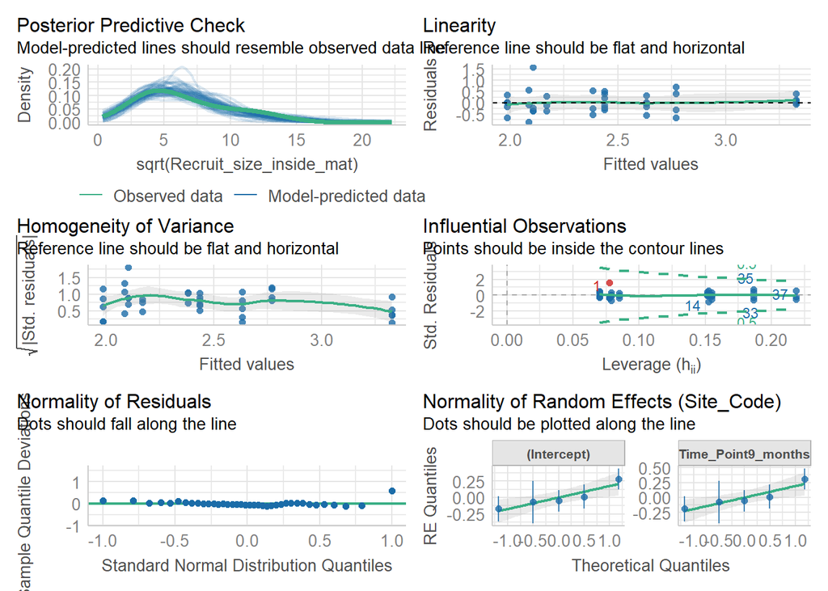

```r
check_model(model4)
```

Individual comparisons

1. Coogee

```r
DensCO <- filter(Recruitment_density, Site_Code == "CO")

wide_data1 <- DensCO %>%
  select(Time_Point, Total_recruitment, Mat_code)
wide_data <- wide_data1 %>%
  pivot_wider(names_from = Time_Point,
              values_from = Total_recruitment)

# paired t-test
t.test(wide_data$`6_months`,
       wide_data$`9_months`,
       paired = TRUE)
```

```
##
##  Paired t-test
##
## data:  wide_data$`6_months` and wide_data$`9_months`
## t = -1.5239, df = 5, p-value = 0.188
## alternative hypothesis: true mean difference is not equal to 0
## 95 percent confidence interval:
##  -30.451121   7.784454
## sample estimates:
## mean difference
##       -11.33333
```

2. Freshwater

```r
DensFW <- filter(Recruitment_density, Site_Code == "FW")

wide_data1 <- DensFW %>%
  select(Time_Point, Total_recruitment, Mat_code)
wide_data <- wide_data1 %>%
  pivot_wider(names_from = Time_Point,
              values_from = Total_recruitment)

# paired t-test
t.test(wide_data$`6_months`,
       wide_data$`9_months`,
       paired = TRUE)
```

```
##
##  Paired t-test
##
## data:  wide_data$`6_months` and wide_data$`9_months`
## t = 2.0702, df = 5, p-value = 0.09322
## alternative hypothesis: true mean difference is not equal to 0
## 95 percent confidence interval:
##  -0.966836  8.966836
## sample estimates:
## mean difference
##               4
```

3. Maroubra

```r
DensMA <- filter(Recruitment_density, Site_Code == "MA")

wide_data1 <- DensMA %>%
  select(Time_Point, Total_recruitment, Mat_code)
wide_data <- wide_data1 %>%
  pivot_wider(names_from = Time_Point,
              values_from = Total_recruitment)

# paired t-test
t.test(wide_data$`6_months`,
       wide_data$`9_months`,
       paired = TRUE)
```

```
##
##  Paired t-test
##
## data:  wide_data$`6_months` and wide_data$`9_months`
## t = 0.88113, df = 5, p-value = 0.4186
## alternative hypothesis: true mean difference is not equal to 0
## 95 percent confidence interval:
##  -1.597796  3.264463
## sample estimates:
## mean difference
##       0.8333333
```

4. South Head

```r
DensSO <- filter(Recruitment_density, Site_Code == "SO")

wide_data1 <- DensSO %>%
  select(Time_Point, Total_recruitment, Mat_code)
wide_data <- wide_data1 %>%
  pivot_wider(names_from = Time_Point,
              values_from = Total_recruitment)

# paired t-test
t.test(wide_data$`6_months`,
       wide_data$`9_months`,
       paired = TRUE)
```

```
##
##  Paired t-test
##
## data:  wide_data$`6_months` and wide_data$`9_months`
## t = 1.4725, df = 5, p-value = 0.2009
## alternative hypothesis: true mean difference is not equal to 0
## 95 percent confidence interval:
##  -0.8700678  3.2034011
## sample estimates:
## mean difference
##        1.166667
```

5. Whale Beach

```r
DensWB <- filter(Recruitment_density, Site_Code == "WB")

wide_data1 <- DensWB %>%
  select(Time_Point, Total_recruitment, Mat_code)
wide_data <- wide_data1 %>%
  pivot_wider(names_from = Time_Point,
              values_from = Total_recruitment)

# paired t-test
t.test(wide_data$`6_months`,
       wide_data$`9_months`,
       paired = TRUE)
```

```
##
##  Paired t-test
##
## data:  wide_data$`6_months` and wide_data$`9_months`
## t = 4, df = 5, p-value = 0.01032
## alternative hypothesis: true mean difference is not equal to 0
## 95 percent confidence interval:
##  0.4764727 2.1901939
## sample estimates:
## mean difference
##        1.333333
```

## **Part 4:** Explore relationships between explanatory variables

In this part we created spreadsheets that included all the relevant variables (Supplementary Table 1) and tested for multicolinearity

### **4a)** Filter data

1. Responses (length and density of recruits)

```r
Rec_site6 <-  Recruitment_density%>%
  filter(Time_Point == "6_months")
Rec_length6 <-  Recruits_length%>%
  filter(Time_Point == "6_months")

Rec_site9 <-  Recruitment_density%>%
  filter(Time_Point == "9_months")
Rec_length9 <-  Recruits_length%>%
  filter(Time_Point == "9_months")
```

2. Benthic data

```r
Benthic_wide_mean<- Benthic_sitemerged %>%
ungroup() %>%
dplyr::select(-n, -sd, -se) %>%
pivot_wider(names_from = Cover_type, values_from = Mean_Cover, values_fill = 0) %>%
dplyr::select("Site_Code", "Understory", "Encrusting_macroalgae", "Ecklonia", "Sargassum")
```

3. Cryptic transect data

```r
Group_wide_2 <- Cryptic_group_mean%>%
ungroup() %>%
dplyr::select(-coef_Sum_Abundance) %>%
pivot_wider(names_from = Functional_group, values_from = Mean_Abundance)


Group_wide_S2 <- Group_wide_2%>%
  filter (Survey_Period == "2") %>%
  dplyr::select("Site_Code", "Omnivorous_fish", "Urchin", "Herbivorous_invert")
```

4. Mobile fish abundance

```r
Herb_Fish <- Funct_fish_herb %>%
  dplyr::select("Site_Code", "Mean_Abundance")
```

5. Richness data

```r
Richness_ALL <- RichnessHerb %>%
  dplyr::select("Site_Code", "Richness")
```

6. Condition

```r
Surv <-  Survival_site%>%
  filter(Time_Point == "6_months") %>%
  dplyr::select("Site_Code", "Survival_Percentage")
Cond <- Condition_site %>%
  dplyr::select("Site_Code", "Percentage_fouling", "Mean_Grazing", "mean_bleaching")
```

7. Gforce

```r
#for mean
Gforce_all <- Gforce_mean%>%
  dplyr::select("Site_Code", "Mean_SD")
```

7. Light intensity

```r
#for mean
Light_all <- Lux_site%>%
  dplyr::select("Site_Code", "Mean_Intensity")
```

9. Temperature

```r
#for mean
Temp_all <- Environmental_site%>%
  dplyr::select("Site_Code",  "Max_temperature",  "Mean_temperature")
```

### **4b)** Combine explanatory variables

```r
All_expvar <- Benthic_wide_mean  %>%
left_join(Group_wide_S2, by = c("Site_Code")) %>%
left_join(Gforce_all, by = c("Site_Code")) %>%
left_join(Light_all, by = c("Site_Code")) %>%
left_join(Richness_ALL, by = c("Site_Code")) %>%
left_join(Temp_all, by = c("Site_Code"))  %>%
left_join(Herb_Fish, by = c("Site_Code")) %>%
left_join(Surv, by = c("Site_Code")) %>%
left_join(Cond, by = c("Site_Code"))


All_expvar_val <- All_expvar %>%
  dplyr::select(- Site_Code)
```

### **4c)** Test for correlations

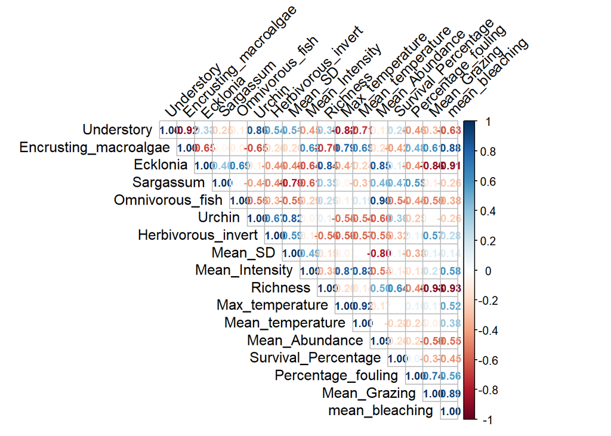

```r
df_cor <- cor(All_expvar_val)
corrplot(df_cor, type = "upper",
         tl.col = "black", tl.srt = 45, method = 'number',
   number.cex=0.75 )
```

Remove variables correlated

```r
Expvar_final <- All_expvar_val %>%
  dplyr::select(-Understory, - Mean_temperature, - Ecklonia, -Omnivorous_fish, - Richness, - mean_bleaching, -Max_temperature)
Expvar_final$Site_Code <- All_expvar$Site_Code
```

### **4d)** Combine responses and explanatory variables

1. Recruitment density 6 months post-transplantation

```r
Rec6 <- Rec_site6 %>%
left_join(Expvar_final, by = c("Site_Code"))
```

2. Recruitment density 9 months post-transplantation

```r
Rec9 <- Rec_site9 %>%
left_join(Expvar_final, by = c("Site_Code"))
```

1. Recruitment length 6 months post-transplantation

```r
Rec_l6 <- Rec_length6 %>%
left_join(Expvar_final, by = c("Site_Code"))
```

1. Recruitment length 9 months post-transplantation

```r
Rec_l9 <- Rec_length9 %>%
left_join(Expvar_final, by = c("Site_Code"))
```

## **Part 5:** Explore individual effects of explanatory variables on recruitment

Check distributions of the response variables

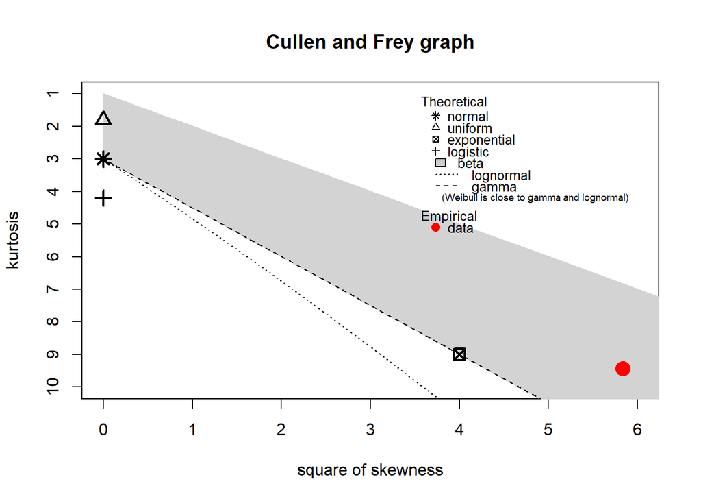

```
## summary statistics
## ------
## min:  0   max:  17
## median:  2
## mean:  3.066667
## estimated sd:  3.894588
## estimated skewness:  2.415433
## estimated kurtosis:  9.441991
```

```r
library(fitdistrplus)
descdist(Rec6$Total_recruitment, discrete = FALSE)
```

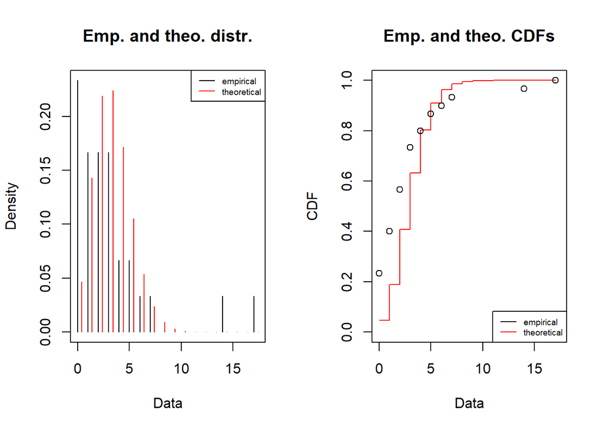

```r
normal_dist <- fitdist(Rec6$Total_recruitment, "pois")
plot(normal_dist)
```

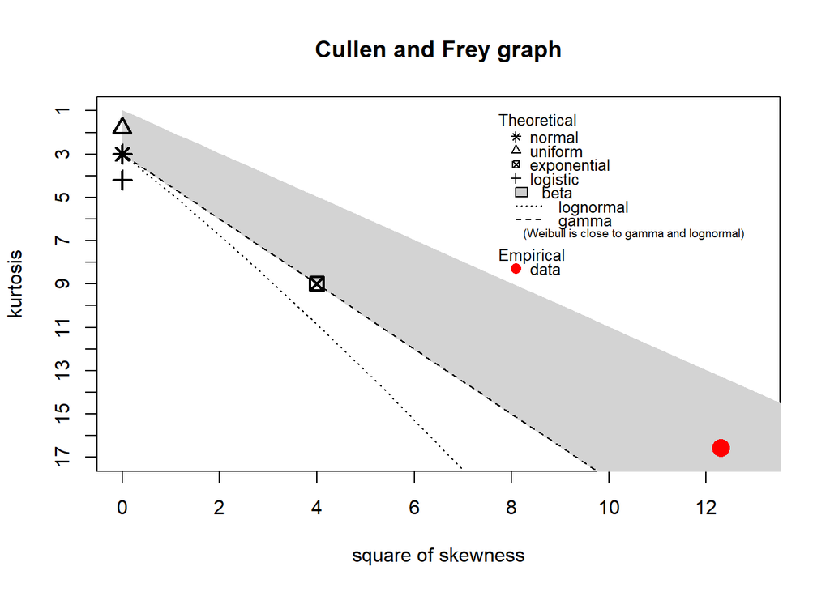

```
## summary statistics
## ------
## min:  0   max:  42
## median:  1
## mean:  3.866667
## estimated sd:  8.637262
## estimated skewness:  3.507862
## estimated kurtosis:  16.57465
```

```r
descdist(Rec9$Total_recruitment, discrete = FALSE)
```

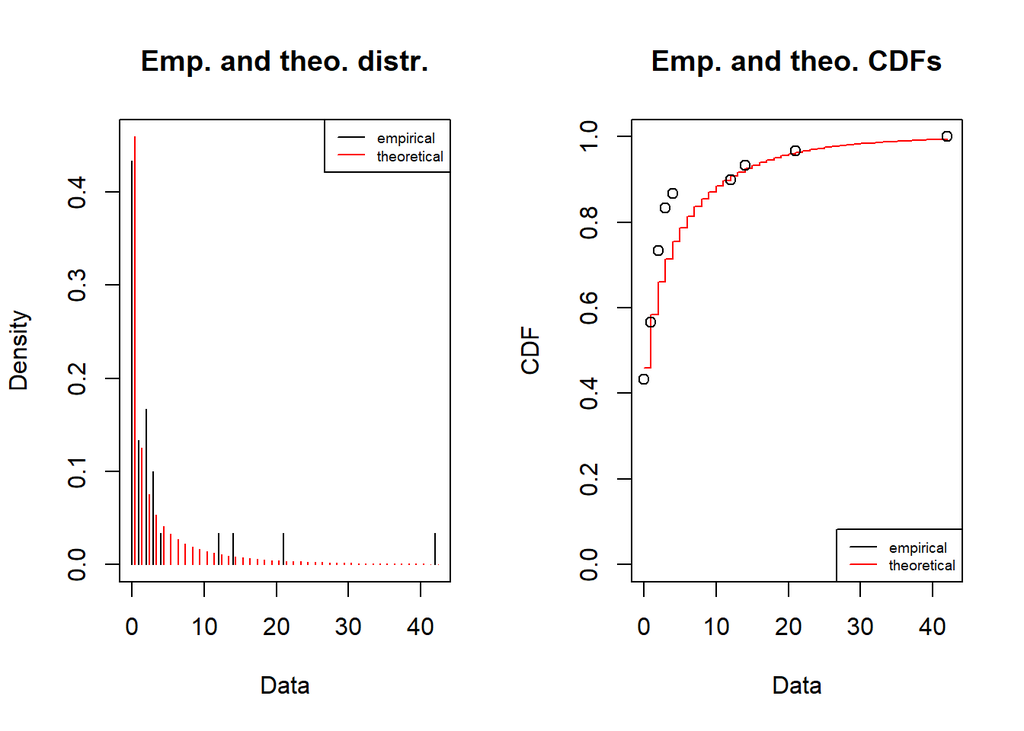

```r
normal_dist <- fitdist(Rec9$Total_recruitment, "nbinom")
plot(normal_dist)
```

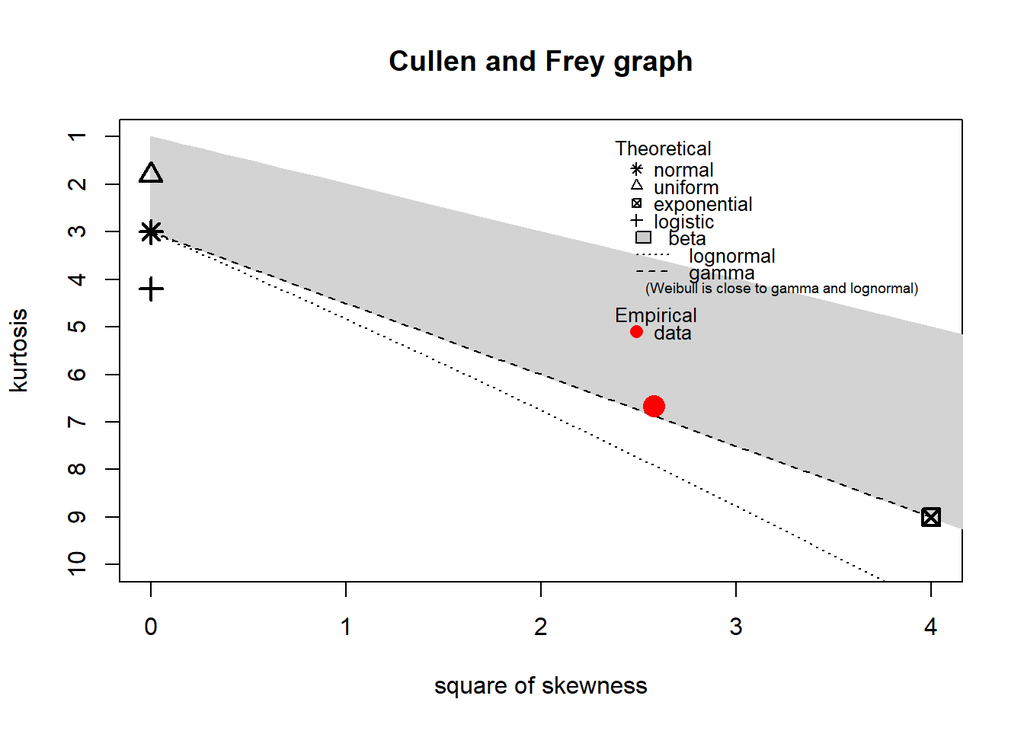

```
## summary statistics
## ------
## min:  1.5   max:  13.5
## median:  4.25
## mean:  5.043197
## estimated sd:  2.709837
## estimated skewness:  1.605633
## estimated kurtosis:  6.67259
```

```r
descdist(Rec_l6$Recruit_size_inside_mat, discrete = FALSE)
```

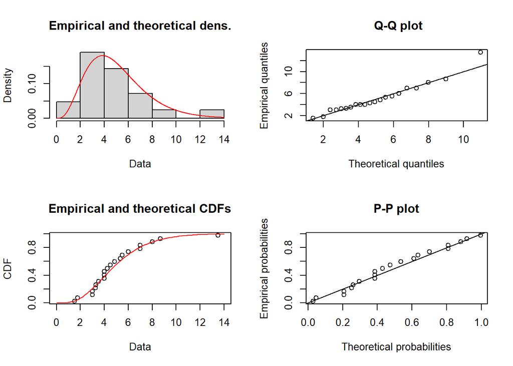

```r
normal_dist <- fitdist(Rec_l6$Recruit_size_inside_mat, "gamma")
plot(normal_dist)
```

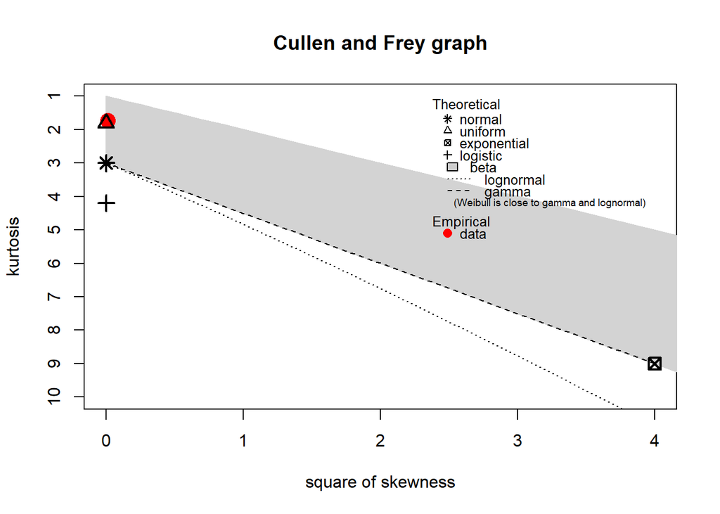

```
## summary statistics
## ------
## min:  3.5   max:  14
## median:  8.5
## mean:  8.291765
## estimated sd:  3.236872
## estimated skewness:  0.1029992
## estimated kurtosis:  1.730555
```

```r
Rec_l9_clean <- Rec_l9 %>% drop_na(Recruit_size_inside_mat)
descdist(Rec_l9_clean$Recruit_size_inside_mat, discrete = FALSE)
```

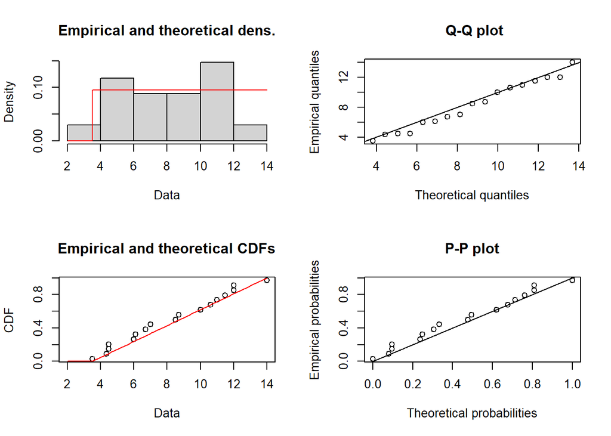

```r
normal_dist <- fitdist(Rec_l9_clean$Recruit_size_inside_mat, "unif")
plot(normal_dist)
```

### **5a)** Recruitment 6 months

1. Abundance of urchins

```r
glm_U <- glmmTMB(Total_recruitment ~ Urchin + (1|Site_Code), data=Rec6, family = nbinom2(link = "log"))
summary(glm_U)
```

```
##  Family: nbinom2  ( log )
## Formula:          Total_recruitment ~ Urchin + (1 | Site_Code)
## Data: Rec6
##
##      AIC      BIC   logLik deviance df.resid
##    141.6    147.2    -66.8    133.6       26
##
## Random effects:
##
## Conditional model:
##  Groups    Name        Variance  Std.Dev.
##  Site_Code (Intercept) 1.952e-08 0.0001397
## Number of obs: 30, groups:  Site_Code, 5
##
## Dispersion parameter for nbinom2 family (): 1.14
##
## Conditional model:
##             Estimate Std. Error z value Pr(>|z|)
## (Intercept) 0.375351   0.492498   0.762    0.446
## Urchin      0.009696   0.006003   1.615    0.106
```

```r
r.squaredGLMM(glm_U)
```

```
##                  R2m        R2c
## delta     0.09316986 0.09316988
## lognormal 0.13532052 0.13532054
## trigamma  0.05392775 0.05392776
```

```r
AICc(glm_U)
```

```
## [1] 143.2448
```

```r
check_model(glm_U)
```

```
## `check_outliers()` does not yet support models of class `glmmTMB`.
```

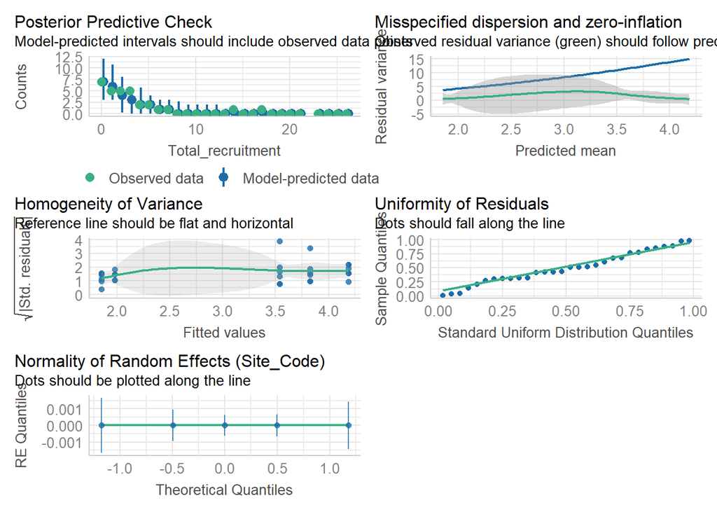

Plot relationship

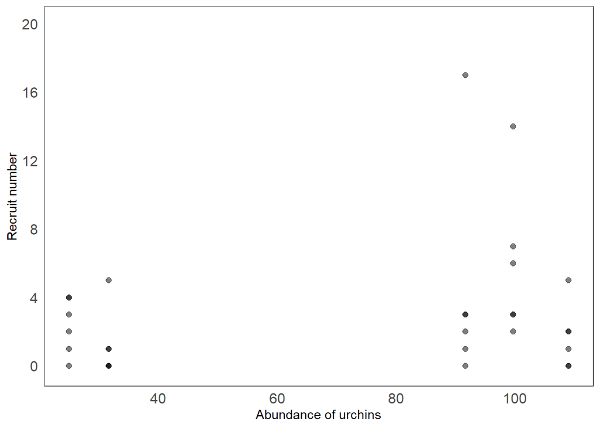

```r
U_Rec6 <- ggplot() +
   geom_point(data = Rec6,                      # adding the raw data (scaled values)
              aes(x = Urchin, y = Total_recruitment), size= 2, alpha=.5) +
   labs(x = "Abundance of urchins", y = expression("Recruit number")) +
   Theme1 +
  scale_y_continuous(limits = c(-0.2, 20), breaks = seq(0,20, by = 4)) +
  theme(axis.title.x=element_text(size = 11), axis.title.y=element_text(size = 11))

U_Rec6
```

2. Abundance of gastropods

```r
glm_U <- glmmTMB(Total_recruitment ~ Herbivorous_invert + (1|Site_Code), data=Rec6, family = nbinom2(link = "log"))
summary(glm_U)
```

```
##  Family: nbinom2  ( log )
## Formula:          Total_recruitment ~ Herbivorous_invert + (1 | Site_Code)
## Data: Rec6
##
##      AIC      BIC   logLik deviance df.resid
##    143.2    148.8    -67.6    135.2       26
##
## Random effects:
##
## Conditional model:
##  Groups    Name        Variance Std.Dev.
##  Site_Code (Intercept) 0.1193   0.3454
## Number of obs: 30, groups:  Site_Code, 5
##
## Dispersion parameter for nbinom2 family (): 1.19
##
## Conditional model:
##                    Estimate Std. Error z value Pr(>|z|)
## (Intercept)         1.15260    0.33113   3.481   0.0005 ***
## Herbivorous_invert -0.06797    0.13510  -0.503   0.6149
## ---
## Signif. codes:  0 '***' 0.001 '**' 0.01 '*' 0.05 '.' 0.1 ' ' 1
```

```r
r.squaredGLMM(glm_U)
```

```
##                   R2m        R2c
## delta     0.014461619 0.10613994
## lognormal 0.020687641 0.15183535
## trigamma  0.008561143 0.06283385
```

```r
AICc(glm_U)
```

```
## [1] 144.8021
```

```r
check_model(glm_U)
```

```
## `check_outliers()` does not yet support models of class `glmmTMB`.
```

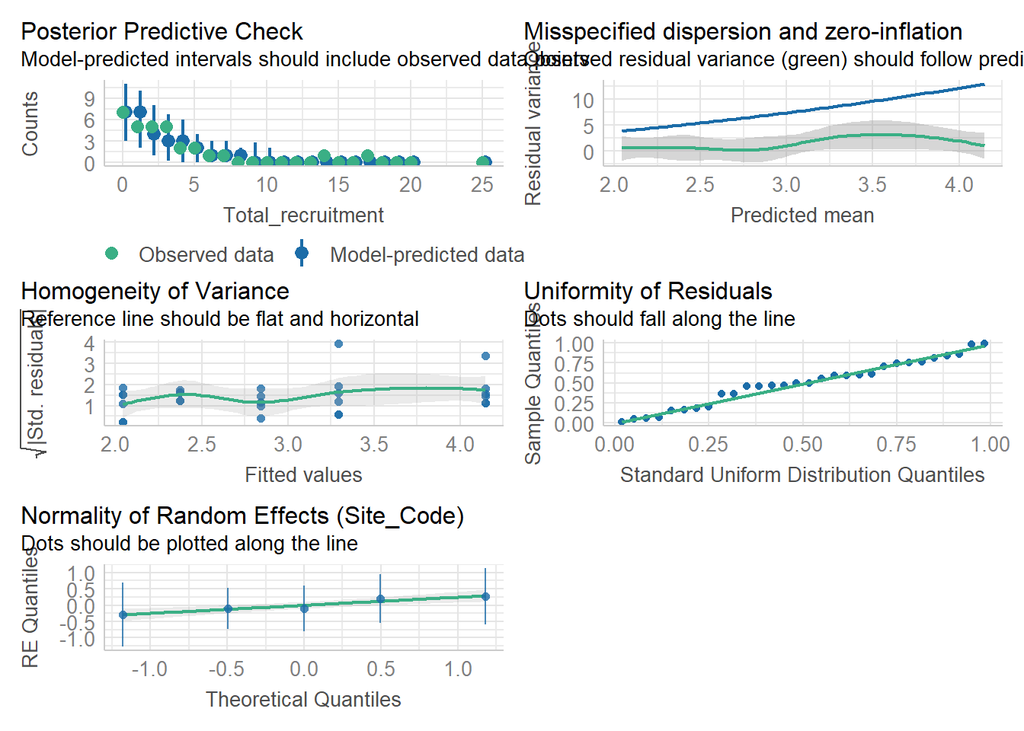

Plot relationship

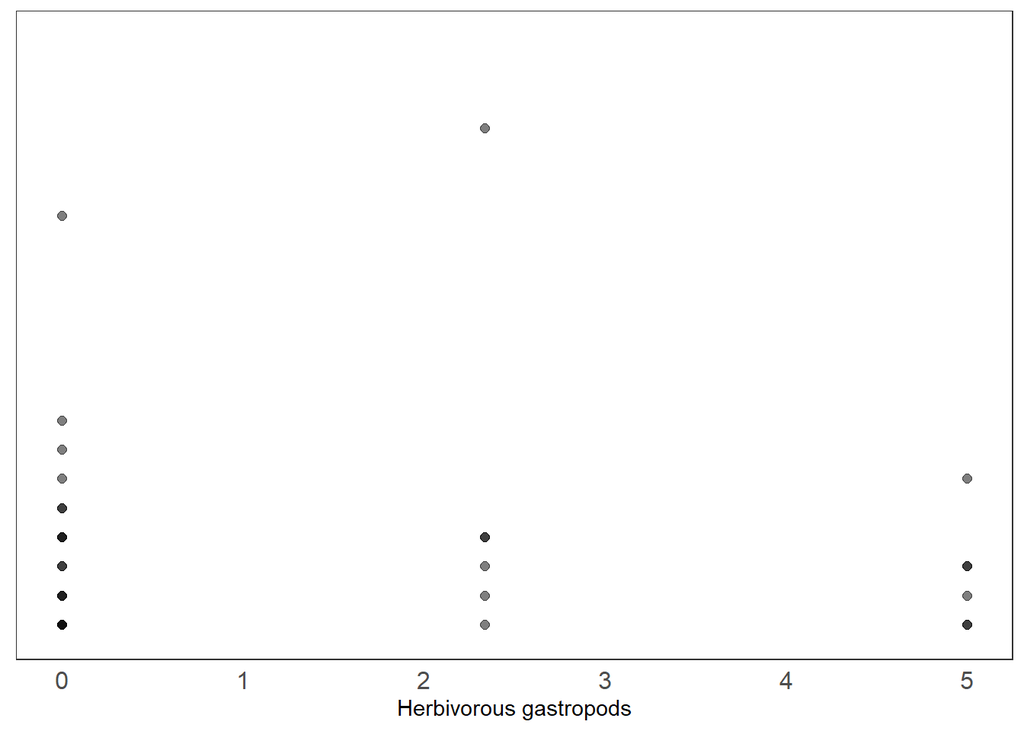

```r
SN_Rec6 <- ggplot() +
   geom_point(data = Rec6,                      # adding the raw data (scaled values)
              aes(x = Herbivorous_invert, y = Total_recruitment), size= 2, alpha=.5) +
   labs(x = "Herbivorous gastropods", y = expression("Total Recruitment")) +
   Theme1 +
  scale_y_continuous(limits = c(-0.2, 20), breaks = seq(0,20, by = 4))+
  theme(axis.title.y=element_blank(),
        axis.text.y=element_blank(), axis.title.x=element_text(size = 11))

SN_Rec6
```

3. Abundance of herbivorous fish

```r
#Linear model (GLM)

glm_HF6 <- glmmTMB(Total_recruitment ~ Mean_Abundance + (1|Site_Code), data=Rec6, family = nbinom2(link = "log"))
summary(glm_HF6)
```

```
##  Family: nbinom2  ( log )
## Formula:          Total_recruitment ~ Mean_Abundance + (1 | Site_Code)
## Data: Rec6
##
##      AIC      BIC   logLik deviance df.resid
##    142.8    148.4    -67.4    134.8       26
##
## Random effects:
##
## Conditional model:
##  Groups    Name        Variance Std.Dev.
##  Site_Code (Intercept) 0.11     0.3316
## Number of obs: 30, groups:  Site_Code, 5
##
## Dispersion parameter for nbinom2 family ():  1.2
##
## Conditional model:
##                Estimate Std. Error z value Pr(>|z|)
## (Intercept)     1.39010    0.48769   2.850  0.00437 **
## Mean_Abundance -0.04325    0.05324  -0.812  0.41657
## ---
## Signif. codes:  0 '***' 0.001 '**' 0.01 '*' 0.05 '.' 0.1 ' ' 1
```

```r
r.squaredGLMM(glm_HF6)
```

```
##                  R2m        R2c
## delta     0.04035369 0.12365604
## lognormal 0.05716404 0.17516811
## trigamma  0.02414573 0.07398991
```

```r
AICc(glm_HF6)
```

```
## [1] 144.414
```

```r
check_overdispersion(glm_HF6)
```

```
## # Overdispersion test
##
##  dispersion ratio = 1.195
##           p-value =  0.56
```

```
## No overdispersion detected.
```

```r
check_model(glm_HF6)
```

```
## `check_outliers()` does not yet support models of class `glmmTMB`.
```

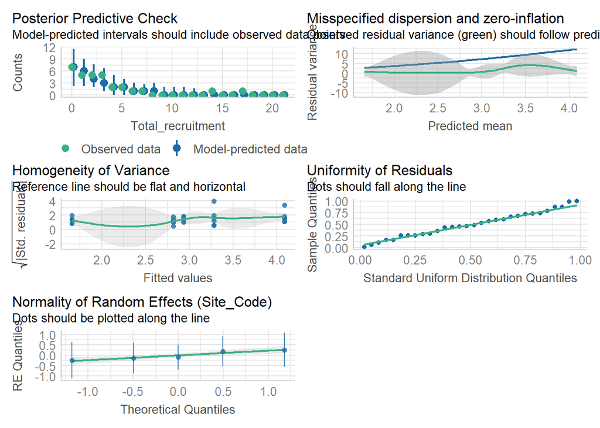

Plot relationship

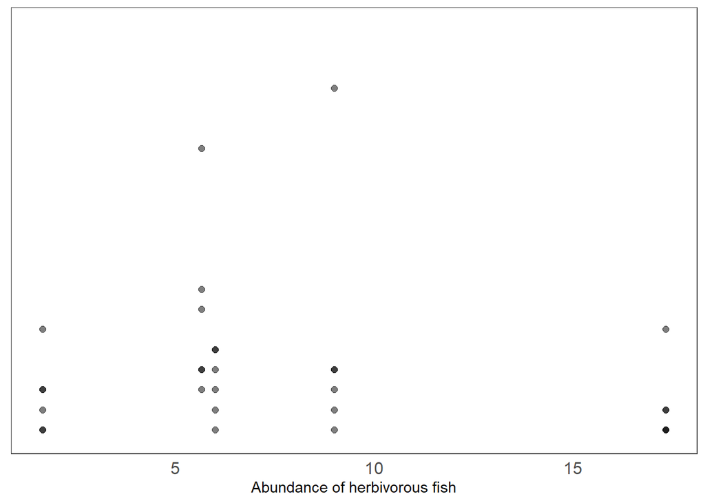

```r
HF_Rec6 <- ggplot() +
   geom_point(data = Rec6,                      # adding the raw data (scaled values)
              aes(x = Mean_Abundance, y = Total_recruitment), size= 2, alpha=.5) +
   labs(x = "Abundance of herbivorous fish", y = "log(Total recruitment)") +
   Theme1 +
  scale_y_continuous(limits = c(-0.2, 20), breaks = seq(0,20, by = 4))+
  theme(axis.title.y=element_blank(),
        axis.text.y=element_blank(), axis.title.x=element_text(size = 11))

HF_Rec6
```

4. Sargassum cover

```r
glm_S <- glmmTMB(Total_recruitment ~ Sargassum + (1|Site_Code), data=Rec6, family = nbinom2(link = "log"))
summary(glm_S)
```

```
##  Family: nbinom2  ( log )
## Formula:          Total_recruitment ~ Sargassum + (1 | Site_Code)
## Data: Rec6
##
##      AIC      BIC   logLik deviance df.resid
##    142.9    148.5    -67.5    134.9       26
##
## Random effects:
##
## Conditional model:
##  Groups    Name        Variance Std.Dev.
##  Site_Code (Intercept) 0.1224   0.3498
## Number of obs: 30, groups:  Site_Code, 5
##
## Dispersion parameter for nbinom2 family (): 1.21
##
## Conditional model:
##             Estimate Std. Error z value Pr(>|z|)
## (Intercept)  0.44102    0.89251   0.494    0.621
## Sargassum    0.03643    0.05055   0.721    0.471
```

```r
r.squaredGLMM(glm_S)
```

```
##                  R2m        R2c
## delta     0.02735571 0.12087356
## lognormal 0.03874787 0.17121079
## trigamma  0.01639155 0.07242747
```

```r
AICc(glm_S)
```

```
## [1] 144.5341
```

```r
check_model(glm_S)
```

```
## `check_outliers()` does not yet support models of class `glmmTMB`.
```

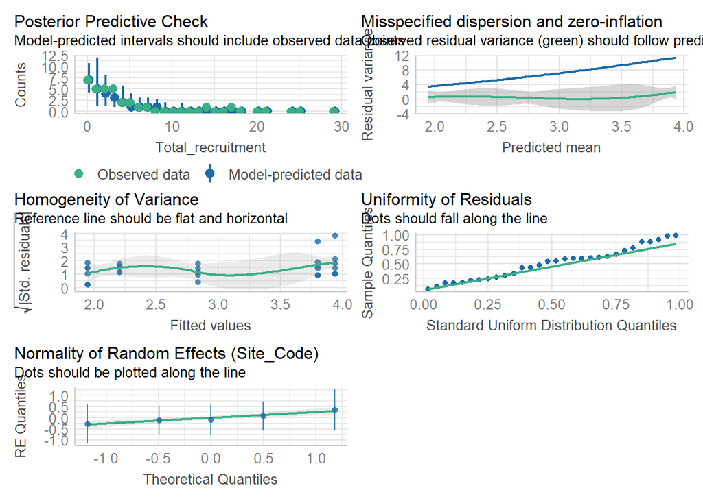

Plot relationships

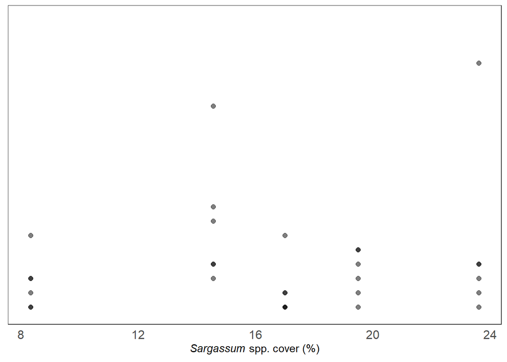

```r
SAR_Rec6 <- ggplot() +
   geom_point(data = Rec6,                      # adding the raw data (scaled values)
              aes(x = Sargassum, y = Total_recruitment), size= 2, alpha=.5) +
   labs(x = expression(paste(italic("Sargassum"), " spp. cover (%)")), y = "log(Total recruitment)") +
   Theme1 +
  scale_y_continuous(limits = c(-0.2, 20), breaks = seq(0,20, by = 4))+
  theme(axis.title.y=element_blank(),
        axis.text.y=element_blank(), axis.title.x=element_text(size = 11))

SAR_Rec6
```

5. CCA cover

```r
glm_S <- glmmTMB(Total_recruitment ~ Encrusting_macroalgae + (1|Site_Code), data=Rec6, family = nbinom2(link = "log"))
summary(glm_S)
```

```
##  Family: nbinom2  ( log )
## Formula:          Total_recruitment ~ Encrusting_macroalgae + (1 | Site_Code)
## Data: Rec6
##
##      AIC      BIC   logLik deviance df.resid
##    142.1    147.7    -67.0    134.1       26
##
## Random effects:
##
## Conditional model:
##  Groups    Name        Variance Std.Dev.
##  Site_Code (Intercept) 0.02766  0.1663
## Number of obs: 30, groups:  Site_Code, 5
##
## Dispersion parameter for nbinom2 family (): 1.16
##
## Conditional model:
##                       Estimate Std. Error z value Pr(>|z|)
## (Intercept)            1.70102    0.51848   3.281  0.00104 **
## Encrusting_macroalgae -0.01918    0.01424  -1.347  0.17793
## ---
## Signif. codes:  0 '***' 0.001 '**' 0.01 '*' 0.05 '.' 0.1 ' ' 1
```

```r
r.squaredGLMM(glm_S)
```

```
##                  R2m        R2c
## delta     0.06293127 0.08431916
## lognormal 0.09140998 0.12247668
## trigamma  0.03656846 0.04899665
```

```r
AICc(glm_S)
```

```
## [1] 143.6859
```